# 102NN slides

### Simple models review and introduction to neural networks

#### 102, Seminar

#### Vivek Yadav, PhD

### Recap

- Linear Regression
- Linear SVM
- Kernel trick: Use nonlinear functions as features
- Use multiple simple functions and combine their outputs

### Linear regression

Objective is to fit a model of type \( y = mx + c \) to noisy data.

- Useful in predicting continuous value outputs
- Example: Predicting steering angle for self-driving car, height of a person from age and weight, etc.

[figure not shown]

### Linear SVM

Objective is to find a plane that best separates a given set of points.

- Useful in classifying a given data set into different groups
- Example: Identifying sentiment of a twitter post, identify emotional expression from image, look at scans and classify them into cancerous or non-cancerous.

[figure not shown]

### Linear methods for nonlinear fitting

1. Convert nonlinear fitting problem to linear task.
2. Apply linear fitting methods.

#### Example: Circle fitting

Equation of circle

[figure not shown]

Rewrite as,

[figure not shown]

Write,

[figure not shown]

Rewrite

[figure not shown]

as

$$ AW = b $$

and solve for W using pseudo-inverse solution as,

$$ W = (A^T A)^{-1} A^{T} b $$

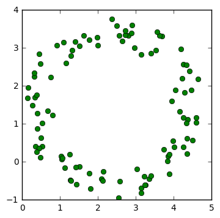

```python
import numpy as np
import matplotlib.pyplot as plt
import time
%pylab inline

th = np.linspace(0,2*3.14,100)

x = 2.+2*np.cos(th) + .8*np.random.rand(len(th))
y = 1.+2*np.sin(th) + .8*np.random.rand(len(th))

plt.figure(figsize=(4,4))
plt.plot(x,y,'go')
```

```python
A = np.vstack((-2*x,-2*y,np.ones(len(x)))).T
b = -(x**2 + y**2)

ATA_inv = np.linalg.inv(np.dot(A.T,A))
Atb = np.dot(A.T,b)
W = np.dot(ATA_inv, Atb)

x_c = W[0]
y_c = W[1]
r = np.sqrt( x_c**2+y_c**2 - W[2])


print(x_c,y_c,r)
```

```
2.39762726913 1.41665543245 2.04485928663
```

[output not shown]

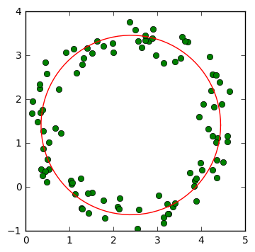

```python
x_fit = x_c+r*np.cos(th)
y_fit = y_c+r*np.sin(th)

plt.figure(figsize=(4,4))
plt.plot(x,y,'go')
plt.plot(x_fit,y_fit,'r')
plt.axis('equal')
```

### Kernel trick

Extension of linear methods to nonlinear systems by taking nonlinear transforms of feature variables.

Example:

[figure not shown]

### Kernel trick for regression

- Gaussian function about each point
- Perform linear regression on gaussian transforms

[figure not shown]

### Kernel trick for SVM

- Gaussian function about each point
- Perform linear regression on gaussian transforms

[figure not shown]

### Combine multiple simple models

- Random forest
- Decision trees

[figure not shown]

### Combine multiple simple models

Classifying by combining multiple linear models.

[figure not shown]

### Limitations of previous methods

- Need to choose weights, nonlinear function, etc manually.
- Do not generalize well to complex data distributions

### Neural networks

- Needn't worry about specifying the exact type of nonlinearity.
- Combine multiple simple models to make complex predictors

[figure not shown]

### Simple neuron compute

[figure not shown]

- Dendrites combine incoming signals from different neurons
- Combine them and transmit to synapses via axons
- Axons are connected to dendrites of other neurons

### Neuron model

[figure not shown]

- Combine large number of simple compute units to achieve complex behavior.

### Neural network model

- Connect multiple simple compute units to form a complex circuit
- Different architectures for different applications
- Deep learning for image/audio/language processing
- Generative networks for producing new data, medicine, drugs, etc.

[figure not shown]

### Chicken and egg problem in neural networks

- Math to explain how brain works, and use brain inspired architectures to make models

#### Perceptron

- First and perhaps simplest neural network model

[figure not shown]

#### Perceptron machine

[figure not shown]

### Vision based neural network models

#### Illusion-1

[figure not shown]

#### Illusion-2

[figure not shown]

#### Grossberg vision model

- Grossberg trying to explain how vision works.
- Proposed field of neurons where each neuron exites itself and neurons in its proximity.

### Convolutional neural networks

[figure not shown]

### Image classification/detection

- Extract features
- Combine feature statistics
- Make decisions based on difference in feature and feature statistics

#### Convolutional neural networks avoid the need for choosing such features.

### Convolutuion operation

[figure not shown]

### Many convolution filters

[figure not shown]

### Applications in medical field

- Imaging, Diabetic retinopathy
- Identifying diseases from brain scans
- Segmentation models to detect tumor.